# **Single Agent Dynamic Discrete Choice: Rust's optimal bus engine replacement**

### Alfred Galichon (NYU & Sciences Po) and Ugo Arena (Sciences Po)

## 'math+econ+code' masterclass series

#### With python code examples

© 2018-2026 by Alfred Galichon. Past and present support from NSF grant DMS-1716489, ERC grant CoG-866274 are acknowledged, as well as inputs from contributors listed [here](http://www.math-econ-code.org/team).

**If you reuse material from this masterclass, please cite as:**  
Alfred Galichon, 'math+econ+code' masterclass. https://github.com/math-econ-code/mec_notebooks

# **References**

Rust, John (1987), Optimal replacement of GMC bus engines: an empirical model of Harold Zurcher. *Econometrica*.

Ferrall, C. (2023). Was Harold Zurcher myopic after all? Replicating Rust's engine replacement estimates. Journal of Applied Econometrics, 38(7), 1093–1100. https://doi.org/10.1002/jae.3001

Galichon, Alfred. Discrete Choice Models: Mathematical Methods, Data Science, and Econometrics. Princeton Univeristy Press.

Galichon, Alfred. "math-econ-code." GitHub. https://github.com/math-econ-code.

Lin, Ranie. "Rust-1987-Replication." GitHub. https://github.com/ranielin/Rust-1987-Replication.

Before detailing the model, it is worth emphasizing this paper's foundational role in the **dynamic discrete choice** literature. Despite its relative simplicity, the structural framework introduced by Rust (1987) remains widely utilized today.The economic agent in this model is **Harold Zurcher**, superintendent of maintenance at the municipal bus depot in Madison, Wisconsin.

# **Quick Model Overview**

Each period, he faces a **discrete binary choice**: replace a given bus engine or keep it running. This constitutes an optimal stopping problem, where the objective is to find a decision rule that perfectly balances the tradeoff between minimizing ongoing maintenance costs and preventing unexpected engine failures. The optimal solution takes the form of a threshold rule, characterized by a critical mileage cutoff, $x^*$.

Rust formalizes a **regenerative optimal stopping problem**.

The State Variable ($x_t$): The accumulated mileage on the bus engine at time $t$.

The Decision ($i_t$): Each month, Zurcher faces a discrete binary choice:

- Keep ($i_t = 0$): Perform regular maintenance and incur operating costs. The bus accumulates more mileage ($x_{t+1} > x_t$).
- Replace ($i_t = 1$): Scrap the old engine and install a new or rebuilt one. This decision "regenerates" the system, resetting the state variable (mileage) back to zero ($x_t = 0$) for the next period.

Every month $t$, Zurcher observes the state of the bus engine, primarily its accumulated mileage $x_t$, and a set of unobserved shocks $\epsilon_t(0)$ and $\epsilon_t(1)$ that affect his costs and then make a choice.

$$u(x_t, i_t, \theta_1) + \epsilon_t(i_t) = \begin{cases} -c(x_t, \theta_1) + \epsilon_t(0) & \text{if } i_t = 0 \text{ (Keep)} \\ -RC - c(0, \theta_1) + \epsilon_t(1) & \text{if } i_t = 1 \text{ (Replace)} \end{cases}$$

Where:

- $c(x_t, \theta_1)$ is the expected regular maintenance and operating cost as a function of mileage. $RC$ is the net replacement cost of installing a new engine.
- $\{\epsilon_t(0), \epsilon_t(1)\}$: Unobserved state variables that Zurcher sees but the econometrician does not.

Zurcher is forward-looking and **wants to maximize his expected discounted utility** over an infinite horizon.

$$V_\theta(x_t, \epsilon_t) = \max_{i \in \{0,1\}} \left[ u(x_t, i, \theta_1) + \epsilon_t(i) + \beta EV_\theta(x_t, \epsilon_t, i) \right]$$

The parameter vector we are estimating is $\theta = (\beta, \theta_1, RC, \theta_3)$ via Maximum Likelihood Estimation:

- $\theta_3$ (Transition Probabilities): How mileage evolves from month to month.
- $\theta_1$ (Maintenance Cost Parameters): How quickly regular costs scale with mileage.
- $RC$ (Replacement Cost Parameter): The cost of an engine swap.
- $\beta$ (Discount Factor): How much Zurcher cares about the future. (Rust tests both a myopic model where $\beta = 0$ and a dynamic model where $\beta = 0.9999$ ).

# **The Data**

We briefly describe the dataset. It comprises maintenance records for **162 buses** spanning from **December 1974 to May 1985**. The data provides **monthly odometer readings** and a **detailed maintenance diary** for each bus. Of the various maintenance tasks recorded, Rust isolates major engine overhauls and replacements. Consequently, the core objective is to estimate a structural model capable of predicting the **time and mileage** at which an **engine replacement** becomes optimal."

We started with **raw text files** (`g870.asc`, `rt50.asc`, etc.) containing unlabelled, column-major matrices.

To make the infinite-horizon dynamic programming computationally tractable, continuous mileage cannot be used as the state variable. Instead, the continuous mileage since the last replacement is **discretized into 5,000-mile bins** (e.g., state 0 is 0-5,000 miles, state 1 is 5,000-10,000 miles, etc.). The following cleaning functions identify the exact months where engine replacements ($i_t=1$) occurred, reset the continuous mileage tracker, and bin the data into these discrete states.

```python
import numpy as np
import pandas as pd
import matplotlib.pyplot as plt
import scipy.optimize as opt
import scipy.stats as stats
!pip install mec
from mec.data import load_Rust_data
```

# **Data Cleaning Part**

```python
# We used NumPy to read the flat files and reshape them into 2D arrays
# using Fortran order (order='F').

base_url = 'https://raw.githubusercontent.com/math-econ-code/mec_datasets/main/dynamicchoice_Rust/datafiles/'

def load_and_reshape(filepath, num_buses):
    url = base_url + filepath
    flat_data = np.loadtxt(url)
    nrow = len(flat_data) // num_buses
    return flat_data.reshape((nrow, num_buses), order='F')

def clean_dat(df_raw, group_num):
    od_rep_1 = df_raw[5, :]
    od_rep_2 = df_raw[8, :]
    df = df_raw[11:, :]

    rep_1 = (df >= od_rep_1) & (od_rep_1 > 0) #The engine is replaced once.
    rep_2 = (df >= od_rep_2) & (od_rep_2 > 0) #The engine is replaced twice.

    mileage_continuous = df.copy()
    mileage_continuous -= (rep_1 & ~rep_2) * od_rep_1
    mileage_continuous -= rep_2 * od_rep_2

    x = np.floor(mileage_continuous / 5000) # We discretize into 5,000-mile bins.

    diff_rep_1 = np.diff(rep_1.astype(int), axis=0)
    diff_rep_2 = np.diff(rep_2.astype(int), axis=0)
    i_inner = ((diff_rep_1 > 0) | (diff_rep_2 > 0)).astype(int)

    zeros_row = np.zeros((1, df.shape[1]), dtype=int)
    i = np.vstack([i_inner, zeros_row])

    num_months, num_buses = df.shape
    bus_ids = np.tile(np.arange(1, num_buses + 1), (num_months, 1))

    time_idx = np.tile(np.arange(1, num_months + 1).reshape(-1, 1), (1, num_buses))

    df_out = pd.DataFrame({
        'group': group_num,
        'bus_id': bus_ids.flatten(order='F'),
        'time_idx': time_idx.flatten(order='F'),
        'raw_odom': df.flatten(order='F'),
        'mileage': mileage_continuous.flatten(order='F'),
        'state_x': x.flatten(order='F'),
        'replace_i': i.flatten(order='F')
    })

    df_out = df_out[df_out['raw_odom'] > 0].copy()
    return df_out

df1_raw = load_and_reshape("g870.asc", 15)
df2_raw = load_and_reshape("rt50.asc", 4)
df3_raw = load_and_reshape("t8h203.asc", 48)
df4_raw = load_and_reshape("a530875.asc", 37)

df1 = clean_dat(df1_raw, group_num=1)
df2 = clean_dat(df2_raw, group_num=2)
df3 = clean_dat(df3_raw, group_num=3)
df4 = clean_dat(df4_raw, group_num=4)

bus_dat = pd.concat([df1, df2, df3, df4], ignore_index=True)
```

# **Table IIa and IIb : Summary of Replacement Data for the uncensored and censored group**

Table IIa summarizes the replacement data for the subsample of buses that **underwent at least one engine replacement**.

```python
#  It increments every time an engine is replaced for a specific bus
bus_dat['replac_id'] = bus_dat.groupby(['group', 'bus_id'])['replace_i'].cumsum()

# Shift_id by 1 so the month of replacement is grouped with the engine being replaced
bus_dat['replac_id'] = bus_dat.groupby(['group', 'bus_id'])['replac_id'].shift().fillna(0)

completed_replac = bus_dat.groupby(['group', 'bus_id', 'replac_id']).filter(lambda x: x['replace_i'].iloc[-1] == 1)

spell_summary = completed_replac.groupby(['group', 'bus_id', 'replac_id']).agg(
    mileage_at_replacement=('mileage', 'max'),
    elapsed_months=('mileage', 'size')
).reset_index()

# We generate Table IIa
table_IIa = spell_summary.groupby('group').agg(
    Mileage_Max=('mileage_at_replacement', 'max'),
    Mileage_Min=('mileage_at_replacement', 'min'),
    Mileage_Mean=('mileage_at_replacement', 'mean'),
    Mileage_Std=('mileage_at_replacement', 'std'),
    Months_Max=('elapsed_months', 'max'),
    Months_Min=('elapsed_months', 'min'),
    Months_Mean=('elapsed_months', 'mean'),
    Months_Std=('elapsed_months', 'std'),
    Observations=('mileage_at_replacement', 'count')
).reset_index()

# We re-index to ensure Groups 1 and 2 show up with 0s (since they get filtered out by having no replacements)
all_groups = pd.DataFrame({'group': [1, 2, 3, 4]})
table_IIa = all_groups.merge(table_IIa, on='group', how='left').fillna(0)
```

```python
# @title
# We round the statistics for clean display
table_IIa = table_IIa.round({'Mileage_Mean': 0, 'Mileage_Std': 0, 'Months_Mean': 1, 'Months_Std': 1})

print("TABLE IIa: SUMMARY OF REPLACEMENT DATA (Groups 1-4)")
print(table_IIa.to_string(index=False))
```

```
TABLE IIa: SUMMARY OF REPLACEMENT DATA (Groups 1-4)
 group  Mileage_Max  Mileage_Min  Mileage_Mean  Mileage_Std  Months_Max  Months_Min  Months_Mean  Months_Std  Observations
     1          0.0          0.0           0.0          0.0         0.0         0.0          0.0         0.0           0.0
     2          0.0          0.0           0.0          0.0         0.0         0.0          0.0         0.0           0.0
     3     273369.0     121326.0      198853.0      37864.0        69.0        30.0         52.9        11.0          27.0
     4     387282.0     120709.0      256417.0      65317.0       112.0        27.0         71.2        22.9          33.0
```

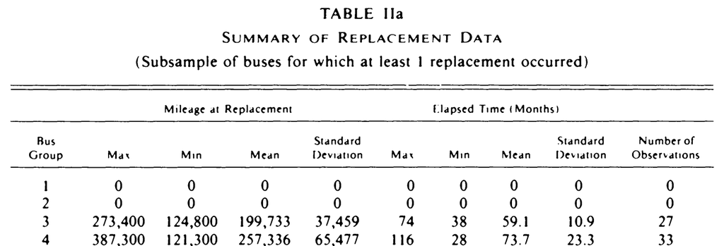

Table IIb presents the right-censored data, representing the subsample of **buses whose engines were not replaced** during the observation period.

```python
bus_dat['elapsed_months'] = bus_dat.groupby(['group', 'bus_id', 'replac_id']).cumcount() + 1

replaced_obs = bus_dat[bus_dat['replace_i'] == 1]

final_rows = bus_dat.groupby(['group', 'bus_id', 'replac_id']).tail(1)
kept_obs = final_rows[final_rows['replace_i'] == 0]
```

```python
replacements_per_bus = bus_dat.groupby(['group', 'bus_id'])['replace_i'].sum()
never_replaced_buses = replacements_per_bus[replacements_per_bus == 0].reset_index()

# We filter our main dataset to only include these censored buses
censored_bus_dat = bus_dat.merge(never_replaced_buses[['group', 'bus_id']], on=['group', 'bus_id'])

# Since they were never replaced, their highest mileage and total elapsed time will be located in the very last row of their data sequence.
final_observations = censored_bus_dat.groupby(['group', 'bus_id']).tail(1)

# We generate Table IIb
table_IIb = final_observations.groupby('group').agg(
    Mileage_Max=('mileage', 'max'),
    Mileage_Min=('mileage', 'min'),
    Mileage_Mean=('mileage', 'mean'),
    Mileage_Std=('mileage', 'std'),
    Months_Max=('elapsed_months', 'max'),
    Months_Min=('elapsed_months', 'min'),
    Months_Mean=('elapsed_months', 'mean'),
    Months_Std=('elapsed_months', 'std'),
    Observations=('bus_id', 'count')
).reset_index()

table_IIb = table_IIb.round({
    'Mileage_Max': 0, 'Mileage_Min': 0, 'Mileage_Mean': 0, 'Mileage_Std': 0,
    'Months_Max': 0, 'Months_Min': 0, 'Months_Mean': 1, 'Months_Std': 2
})

print("TABLE IIb: CENSORED DATA (Groups 1-4)")
print(table_IIb.to_string(index=False))
```

```
TABLE IIb: CENSORED DATA (Groups 1-4)
 group  Mileage_Max  Mileage_Min  Mileage_Mean  Mileage_Std  Months_Max  Months_Min  Months_Mean  Months_Std  Observations
     1     120151.0      65643.0      100117.0      12929.0          25          25         25.0         0.0            15
     2     161748.0     142009.0      151182.0       8530.0          49          49         49.0         0.0             4
     3     280802.0     199626.0      250766.0      21325.0          70          70         70.0         0.0            21
     4     352450.0     310910.0      337222.0      17802.0         117         117        117.0         0.0             5
```

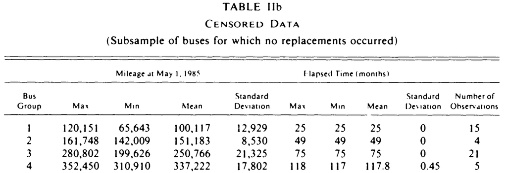

Following Rust, we restrict our focus to bus **groups 1 through 4**. The buses in these groups were the **newest in the fleet** and were used on the most active routes. Rust isolates these specific groups for two main reasons: the availability of reliable replacement cost data, and the fact that the monthly mileage distributions for each bus are **relatively homogeneous** within each group. Because the estimation procedure allows for between-group heterogeneity but assumes **within-group homogeneity**, selecting the **most uniform groups** is theoretically justified.

# **Figure 1: Bus Replacement Data: Full Sample**

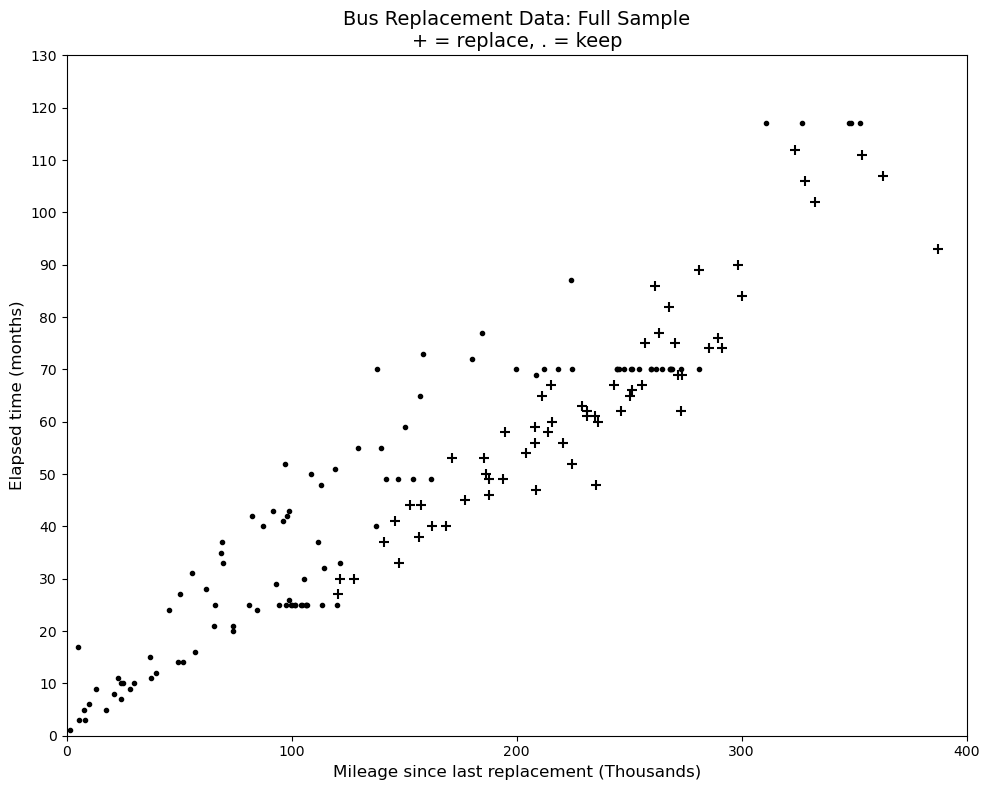

```python
# @title
plt.figure(figsize=(10, 8))

plt.scatter(
    kept_obs['mileage'] / 1000,
    kept_obs['elapsed_months'],
    marker='.',
    color='black',
    label=f'keep ({len(kept_obs)} obs)'
)

plt.scatter(
    replaced_obs['mileage'] / 1000,
    replaced_obs['elapsed_months'],
    marker='+',
    color='black',
    s=60,
    label=f'replace ({len(replaced_obs)} obs)'
)

plt.title('Bus Replacement Data: Full Sample\n+ = replace, . = keep', fontsize=14)
plt.xlabel('Mileage since last replacement (Thousands)', fontsize=12)
plt.ylabel('Elapsed time (months)', fontsize=12)

plt.xlim(0, 400)
plt.ylim(0, 130)

plt.xticks(range(0, 401, 100))
plt.yticks(range(0, 131, 10))

plt.tight_layout()
plt.show()
```

Figure 1 illustrates the **considerable variation in both the time and mileage at which bus engine replacements occur**, ranging roughly from 125,000 to over 300,000 miles. This wide dispersion contradicts the naive hypothesis of a single, strictly deterministic stopping barrier. Consequently, this variance motivates the core premise of Rust's structural model: Zurcher's replacement decisions are not based solely on observed odometer readings, but are also driven by other state variables that are known to him but remain unobserved by the econometrician.

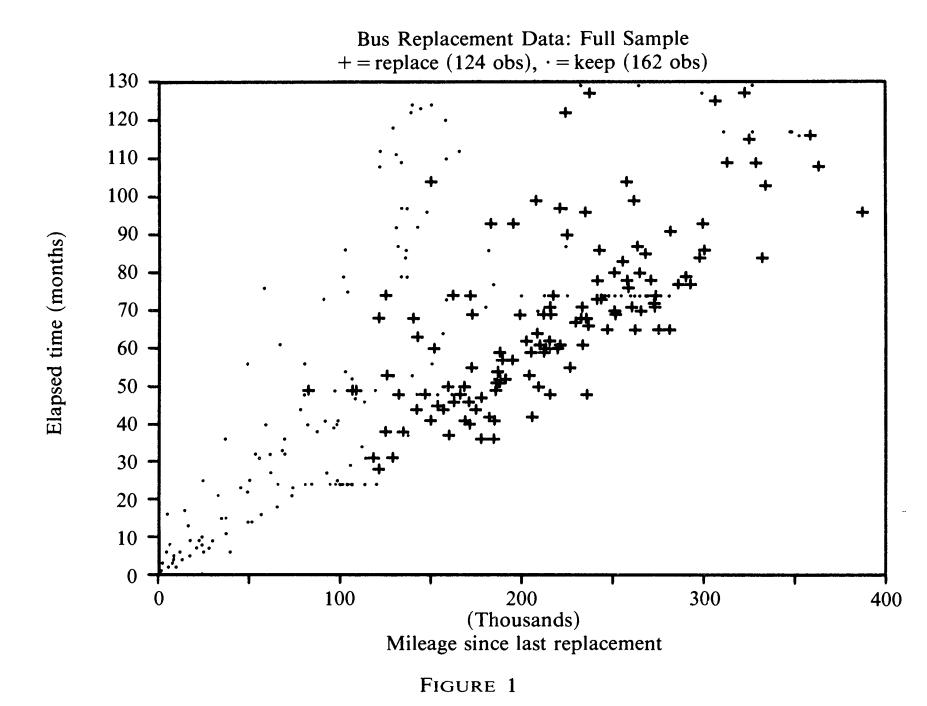

# **Table V and VI: Within Group and Between Group Estimates of Mileage Process**

Since we discretized mileage into **5,000-mile bins** (90 intervals of 5,000 miles, same as Rust)., a bus will typically "jump" by 0, 1, or 2 bins in a single month. We define $\theta_3$ as the set of transition probabilities:

- **$\theta_{30}$**: Probability of advancing 0 bins (transitionning from state $x$ to state $x$).
- **$\theta_{31}$**: Probability of advancing 1 bin (transitionning from state $x$ to state $x+1$).
- **$\theta_{32}$**: Probability of advancing 2+ bins (transitionning from state $x$ to state $x+2$).

# **Table V**

```python
def get_mileage_transitions(df):
    df = df.sort_values(by=['bus_id', 'time_idx']).copy()

    df['prev_state_x'] = df.groupby('bus_id')['state_x'].shift(1)
    df['prev_replace_i'] = df.groupby('bus_id')['replace_i'].shift(1)

    valid_transitions = df.dropna(subset=['prev_state_x']).copy()

    jumps = np.where(
        valid_transitions['prev_replace_i'] == 1,
        valid_transitions['state_x'],
        valid_transitions['state_x'] - valid_transitions['prev_state_x']
    )

    valid_jumps = jumps[jumps >= 0]
    valid_jumps = np.clip(valid_jumps, 0, 2)

    return valid_jumps.astype(int)

def estimate_transition_parameters(jumps):
    n_obs = len(jumps)
    counts = np.bincount(jumps, minlength=3)
    theta = counts / n_obs
    ll = np.sum(counts * np.log(np.where(theta > 0, theta, 1e-10)))
    return theta, ll, n_obs
```

```python
# @title
# We generate Table V: Within Group Estimates
print("TABLE V: WITHIN GROUP ESTIMATES OF MILEAGE PROCESS")
print("-" * 65)
print(f"{'Group':<10} | {'Theta 31':<12} | {'Theta 32':<12} | {'Theta 33 | Restricted Log-Like'}")
print("-" * 65)

group_results = {}
for g in [1, 2, 3, 4]:
    jumps = get_mileage_transitions(bus_dat[bus_dat['group'] == g])
    theta, ll, n_obs = estimate_transition_parameters(jumps)
    group_results[g] = {'theta': theta, 'll': ll, 'n_obs': n_obs, 'jumps': jumps}

    print(f"Group {g:<4} | {theta[0]:.4f}       | {theta[1]:.4f}       | {theta[2]:.4f}        | {ll:.2f}")
```

```
TABLE V: WITHIN GROUP ESTIMATES OF MILEAGE PROCESS
-----------------------------------------------------------------
Group      | Theta 31     | Theta 32     | Theta 33 | Restricted Log-Like
-----------------------------------------------------------------
Group 1    | 0.1972       | 0.7889       | 0.0139        | -203.99
Group 2    | 0.3906       | 0.5990       | 0.0104        | -138.57
Group 3    | 0.3149       | 0.6751       | 0.0100        | -2235.67
Group 4    | 0.3996       | 0.5876       | 0.0128        | -3153.83
```

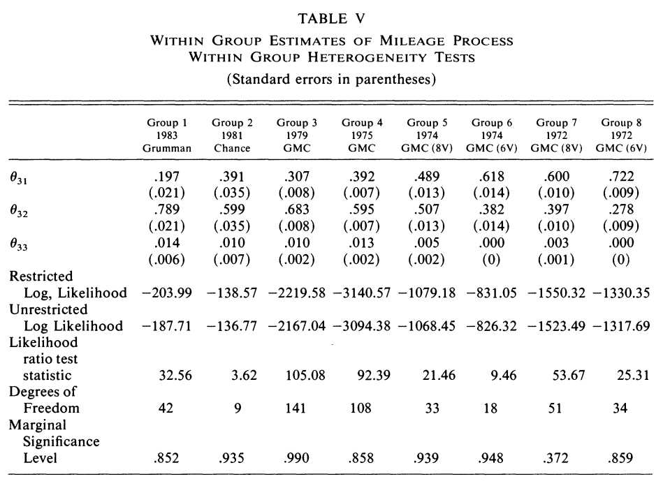

**Do individual buses within the same group accumulate mileage at the same rate?**

# **Table VI**

```python
# We need a 3-state transition function (as we discretizes with 5,000 miles bins (no city bus will ever drive more than 15,000 miles in a given month)).
def get_mileage_transitions_3state(df):
    df = df.sort_values(by=['group', 'bus_id', 'time_idx']).copy()
    df['prev_state_x'] = df.groupby(['group', 'bus_id'])['state_x'].shift(1)
    df['prev_replace_i'] = df.groupby(['group', 'bus_id'])['replace_i'].shift(1)
    valid_transitions = df.dropna(subset=['prev_state_x']).copy()

    jumps = np.where(
        valid_transitions['prev_replace_i'] == 1,
        valid_transitions['state_x'],
        valid_transitions['state_x'] - valid_transitions['prev_state_x']
    )
    valid_jumps = jumps[jumps >= 0]
    valid_jumps = np.clip(valid_jumps, 0, 2)
    return valid_jumps.astype(int)

def estimate_transition_parameters_3state(jumps):
    n_obs = len(jumps)
    counts = np.bincount(jumps, minlength=3)
    theta = counts / n_obs
    ll = np.sum(counts * np.log(np.where(theta > 0, theta, 1e-10)))
    return theta, ll

# We generate Table VI: Between Group Estimates
print("\nTABLE VI: BETWEEN GROUP ESTIMATES OF MILEAGE PROCESS")
print("-" * 85)
print(f"{'Groups Pooled':<15} | {'Theta 30':<8} | {'Theta 31':<8} | {'Theta 32':<8} | {'Restricted LL':<15} | {'LR Stat':<10}")
print("-" * 85)

pooled_definitions = {
    '1, 2, 3, 4': [1, 2, 3, 4],
    '1, 2, 3': [1, 2, 3]
}

for label, groups in pooled_definitions.items():
    # Restricted Model
    pooled_data = bus_dat[bus_dat['group'].isin(groups)]
    combined_jumps = get_mileage_transitions_3state(pooled_data)

    theta_restricted, ll_restricted = estimate_transition_parameters_3state(combined_jumps)

    # Unrestricted Model (We estimate separately for every individual bus)
    ll_unrestricted = 0

    # We identify unique buses by their group and bus_id.
    unique_buses = pooled_data[['group', 'bus_id']].drop_duplicates()
    num_buses = len(unique_buses)

    for _, row in unique_buses.iterrows():
        # We isolate the exact bus using both identifiers
        bus_jumps = get_mileage_transitions_3state(
            pooled_data[(pooled_data['group'] == row['group']) & (pooled_data['bus_id'] == row['bus_id'])]
        )
        if len(bus_jumps) > 0:
            _, ll_bus = estimate_transition_parameters_3state(bus_jumps)
            ll_unrestricted += ll_bus

    # LR Test Statistic
    lr_stat = -2 * (ll_restricted - ll_unrestricted)

    # Degrees of Freedom
    df = (num_buses - 1) * 3

    p_val = stats.chi2.sf(lr_stat, df)

    print(f"{label:<15} | {theta_restricted[0]:.4f}   | {theta_restricted[1]:.4f}   | {theta_restricted[2]:.4f}   | {ll_restricted:<15.2f} | {lr_stat:.2f}")
    print(f"  LR Test (df={df}): {p_val:.4f}\n")
```

```
TABLE VI: BETWEEN GROUP ESTIMATES OF MILEAGE PROCESS
-------------------------------------------------------------------------------------
Groups Pooled   | Theta 30 | Theta 31 | Theta 32 | Restricted LL   | LR Stat
-------------------------------------------------------------------------------------
1, 2, 3, 4      | 0.3561   | 0.6323   | 0.0116   | -5785.82        | 335.76
  LR Test (df=309): 0.1416

1, 2, 3         | 0.3077   | 0.6819   | 0.0104   | -2592.90        | 166.64
  LR Test (df=198): 0.9489
```

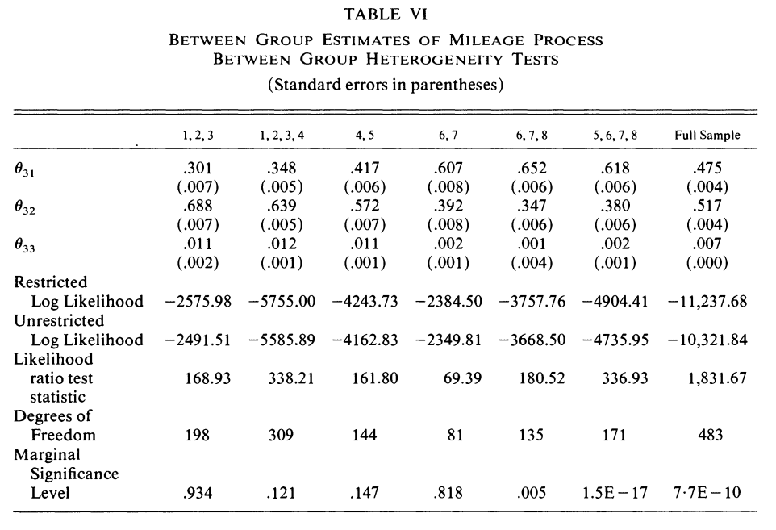

# **Table IX: Structural Estimates for Cost Function**

Our maximum likelihood estimation of the dynamic discrete choice model requires a **nested fixed-point algorithm**.

**The Inner Loop: Solving the Fixed Point**

For Zurcher to make a decision, he needs to know the expected long-term costs of keeping versus replacing the engine. For a given set of cost parameters, we **iteratively solve the Bellman equation** to compute the expected value function (the **fixed point**). This quantifies the forward-looking expected discounted utility of the decision-maker. Once the fixed point is found, the inner loop can translate those expected values into **Choice Probabilities**.

**The Outer Loop: Maximum Likelihood**

We use the derived expected value functions and unobserved shock distributions to calculate the **conditional probability** of Zurcher choosing to replace or keep the engine. We construct the **log-likelihood function and use an optimization routine to maximize it** with respect to the cost parameters ($\theta_1$ and $RC$).

We run this estimation routine for different assumptions about how much Zurcher cares about the future. Specifically, test a myopic model (setting the discount factor $\beta = 0$) and a dynamic model (setting $\beta = 0.9999$).

```python
# --
# INNER LOOP: Value Function Iteration (Contraction Mapping)
# --
def solve_dynamic_program(RC, theta_1, theta_3, beta, n_states=90, tol=1e-6):
    """
    Computes the Expected Value function for a given set of parameters.
    """
    # We use a Linear Specification: c(x) = theta_1 * x)
    states = np.arange(n_states)
    maint_cost = theta_1 * states * 0.001

    # We build Transition Matrices based on Stage 1 estimates (theta_3)
    P_keep = np.zeros((n_states, n_states))
    P_replace = np.zeros((n_states, n_states))

    for i in range(n_states):
        P_keep[i, i] = theta_3[0]
        if i + 1 < n_states:
            P_keep[i, i+1] = theta_3[1]
        else:
            P_keep[i, i] += theta_3[1]
        if i + 2 < n_states:
            P_keep[i, i+2] = theta_3[2]
        else:
            P_keep[i, -1] += theta_3[2]

        P_replace[i, 0] = theta_3[0]
        P_replace[i, 1] = theta_3[1]
        P_replace[i, 2] = theta_3[2]

    # We run the Contraction Mapping
    EV = np.zeros(n_states) # Initial guess for Expected Value

    max_iter = 2000
    for _ in range(max_iter):
        # Choice-specific value functions: V(x, d) = u(x, d) + beta * E[EV(x')]

        # If Keep: Pay maintenance cost, state transitions normally
        v_keep = -maint_cost + beta * (P_keep @ EV)

        # If Replace: Pay RC and maintenance for state 0, state resets
        v_replace = -RC - maint_cost[0] + beta * (P_replace @ EV)

        # Log-sum formula
        # EV_new = ln(exp(v_keep) + exp(v_replace))
        max_v = np.maximum(v_keep, v_replace)
        EV_new = max_v + np.log(np.exp(v_keep - max_v) + np.exp(v_replace - max_v))

        if np.max(np.abs(EV_new - EV)) < tol:
            break
        EV = EV_new

    return EV, v_keep, v_replace

# --
# OUTER LOOP: Maximum Likelihood Estimation
# --
def negative_log_likelihood(params, df, theta_3, beta):
    """
    Calculates the negative log-likelihood of the observed choices given parameters.
    """
    RC, theta_1 = params

    # We run the inner loop to find Harold Zurcher's optimal policy for these params
    EV, v_keep, v_replace = solve_dynamic_program(RC, theta_1, theta_3, beta)

    state = df['state_x'].values.astype(int)
    choice = df['replace_i'].values.astype(int)

    # We get the choice-specific values for the observed states in the data
    v_k = v_keep[state]
    v_r = v_replace[state]

    # We calculate log choice probabilities
    max_v = np.maximum(v_k, v_r)
    log_sum = max_v + np.log(np.exp(v_k - max_v) + np.exp(v_r - max_v))

    # P(d=0 | x) and P(d=1 | x)
    log_prob_keep = v_k - log_sum
    log_prob_replace = v_r - log_sum

    # We sum the log-likelihood of the actual choices made in the data
    ll_array = np.where(choice == 1, log_prob_replace, log_prob_keep)
    ll = np.sum(ll_array)

    return -ll
```

```python
# -- We replicate Table IX for Beta = 0.9999 and Beta = 0.0 --
print("-" * 85)
print(f"{'TABLE IX: STRUCTURAL ESTIMATES (LINEAR COST SPECIFICATION)':^85}")
print("-" * 85)

groups_to_run = {
    'Groups 1, 2, 3': [1, 2, 3],
    'Group 4': [4],
    'Groups 1, 2, 3, 4': [1, 2, 3, 4]
}

betas_to_test = [0.9999, 0.0]
results = {beta: {} for beta in betas_to_test}

for beta in betas_to_test:
    for name, grps in groups_to_run.items():
        df_pool = bus_dat[bus_dat['group'].isin(grps)]
        jumps = get_mileage_transitions_3state(df_pool)
        theta_3, ll_stage1 = estimate_transition_parameters_3state(jumps)

        res = opt.minimize(
            negative_log_likelihood,
            [10.0, 2.0],
            args=(df_pool, theta_3, beta),
            method='L-BFGS-B',
            bounds=[(0, None), (0, None)],
            options={'ftol': 1e-5}
        )

        results[beta][name] = {
            'RC': res.x[0],
            'theta_1': res.x[1],
            'theta_3': theta_3,
            'll_stage2': -res.fun,
            'll_stage1': ll_stage1,
            'full_ll': ll_stage1 - res.fun
        }

# We display Table IX
for beta in betas_to_test:
    print(f"\n>> DISCOUNT FACTOR: Beta = {beta}")
    print(f"{'Parameter':<25} | {'Groups 1, 2, 3':<17} | {'Group 4':<17} | {'Groups 1, 2, 3, 4'}")
    print("-" * 85)
    print(f"{'Replacement Cost (RC)':<25} | {results[beta]['Groups 1, 2, 3']['RC']:<17.4f} | {results[beta]['Group 4']['RC']:<17.4f} | {results[beta]['Groups 1, 2, 3, 4']['RC']:.4f}")
    print(f"{'Maintenance Cost (Theta 1)':<25} | {results[beta]['Groups 1, 2, 3']['theta_1']:<17.4f} | {results[beta]['Group 4']['theta_1']:<17.4f} | {results[beta]['Groups 1, 2, 3, 4']['theta_1']:.4f}")
    print("-" * 85)
    if beta == 0.9999:
        print(f"{'Theta 30 (Jump = 0)':<25} | {results[beta]['Groups 1, 2, 3']['theta_3'][0]:<17.4f} | {results[beta]['Group 4']['theta_3'][0]:<17.4f} | {results[beta]['Groups 1, 2, 3, 4']['theta_3'][0]:.4f}")
        print(f"{'Theta 31 (Jump = 1)':<25} | {results[beta]['Groups 1, 2, 3']['theta_3'][1]:<17.4f} | {results[beta]['Group 4']['theta_3'][1]:<17.4f} | {results[beta]['Groups 1, 2, 3, 4']['theta_3'][1]:.4f}")
        print("-" * 85)
    print(f"{'Full Log-Likelihood':<25} | {results[beta]['Groups 1, 2, 3']['full_ll']:<17.2f} | {results[beta]['Group 4']['full_ll']:<17.2f} | {results[beta]['Groups 1, 2, 3, 4']['full_ll']:.2f}")
```

```
-------------------------------------------------------------------------------------
             TABLE IX: STRUCTURAL ESTIMATES (LINEAR COST SPECIFICATION)
-------------------------------------------------------------------------------------

>> DISCOUNT FACTOR: Beta = 0.9999
Parameter                 | Groups 1, 2, 3    | Group 4           | Groups 1, 2, 3, 4
-------------------------------------------------------------------------------------
Replacement Cost (RC)     | 11.7247           | 9.9281            | 9.7696
Maintenance Cost (Theta 1) | 4.7905            | 2.2201            | 2.6164
-------------------------------------------------------------------------------------
Theta 30 (Jump = 0)       | 0.3077            | 0.3996            | 0.3561
Theta 31 (Jump = 1)       | 0.6819            | 0.5876            | 0.6323
-------------------------------------------------------------------------------------
Full Log-Likelihood       | -2725.28          | -3317.42          | -6086.07

>> DISCOUNT FACTOR: Beta = 0.0
Parameter                 | Groups 1, 2, 3    | Group 4           | Groups 1, 2, 3, 4
-------------------------------------------------------------------------------------
Replacement Cost (RC)     | 8.3087            | 7.6417            | 7.3154
Maintenance Cost (Theta 1) | 110.1428          | 71.6201           | 70.4670
-------------------------------------------------------------------------------------
Full Log-Likelihood       | -2727.66          | -3319.31          | -6092.54
```

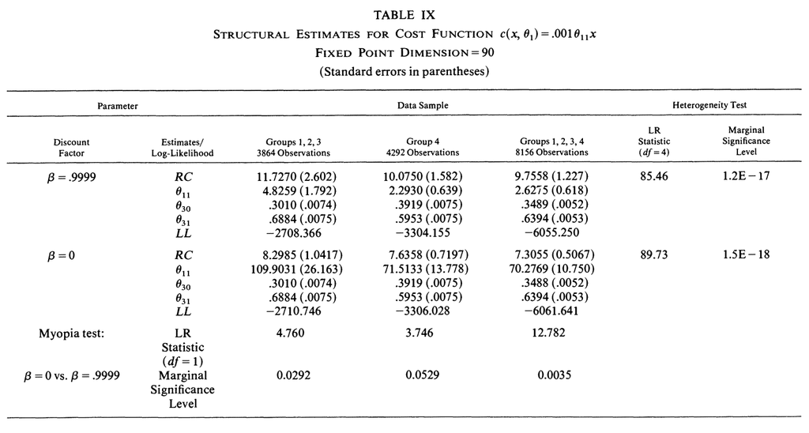